# AlaskaSalmon

Andrea Odell

May 25, 2018

# Alaska Salmon

This project is part of a class exercise where we create mini projects of our own. My project uses salmon spatial and biological data from A and C creek in Alaska collected from 2004 to 2016.

## Setting Up

We read in the file that we have that contains the spatial and biological data as well as the file that interprets spatial data into more recognizeable numerical values

```r
master <- read.csv("data/autocorrelation_sections_corrected_051118_final.csv", na.strings = "NA")
distances <- read.csv("data/creek_midpoint.csv")
```

## Cleaning up raw data

```r
## adding a column for distance of fish based on location_section
master_with_distance <-  cbind(master,midpoint=rep(master$location_section))


### replace section location values in midpoint column with midpoint values.
master_with_distance$midpoint <- distances$midpoint[match(master_with_distance$midpoint, distances$section)]


#remove unnecessary data in Location and Sex column to merge similar vectors
master_with_distance$Location[master_with_distance$Location == "A" |
                                master_with_distance$Location == "amouth" |
                                master_with_distance$Location == "am" |
                                master_with_distance$Location == "abeach"] <- "a"
master_with_distance$Location[master_with_distance$Location == "cm" |
                                master_with_distance$Location == "cbeach" |
                                master_with_distance$Location == "cmouth"] <- "c"

tolower <- master_with_distance$Sex
target_sex <- c("f", "m")
master_with_distance <- master_with_distance %>%
  filter(Sex %in% target_sex)
```

## Population dynamics

```r
## subsetting data we need

fish_per_year <- master_with_distance %>%
  group_by(Year)

### How many fish per year showing m:f ratio

sex_ratio_fish_count <- ggplot(fish_per_year, aes(x = Year, color = Sex)) +
  geom_histogram()


### how many fish per year showing a creek: c creek ratio

creek_ratio_fish_count <- ggplot(fish_per_year, aes(x = Year, color = Location)) +
  geom_histogram()
```

## Return times and distances each year between creeks

We must look at each creek and year separately. This didn’t reveal ny trends but data may need more cleaning up. **MUST** make edits to years and names accordingly when using this code. *The only year’s available are 2004-2016*.

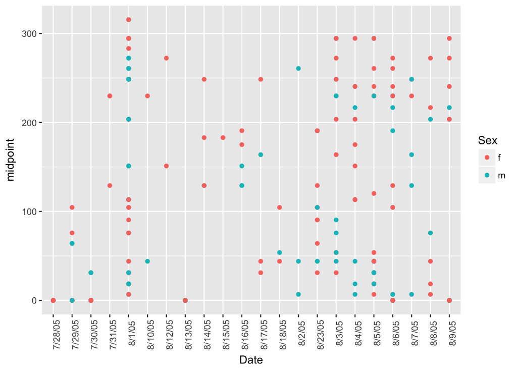

```r
# A creek fish in *year*
acreek_fish_2005_return_time <- master_with_distance %>%
  filter(Year == "2005") %>%    ### Edit year here - then fix name to match year
  group_by(Tag) %>%
  filter(Date == first(Date)) %>%
  filter(Location == "a")

# C creek fish in *year*
ccreek_fish_2005_return_time <- master_with_distance %>%
  filter(Year == "2005") %>%  ### Edit year here - then fix name to match year
  group_by(Tag) %>%
  filter(Date == first(Date)) %>%
  filter(Location == "c")

## create a scatter plot graph
ggplot(acreek_fish_2005_return_time, aes(x = Date, y = midpoint, color = Sex)) +
  geom_point() +
  theme(axis.text.x = element_text(angle = 90, hjust =0.75))   # plot for a creek  - edit name to match year you want
```

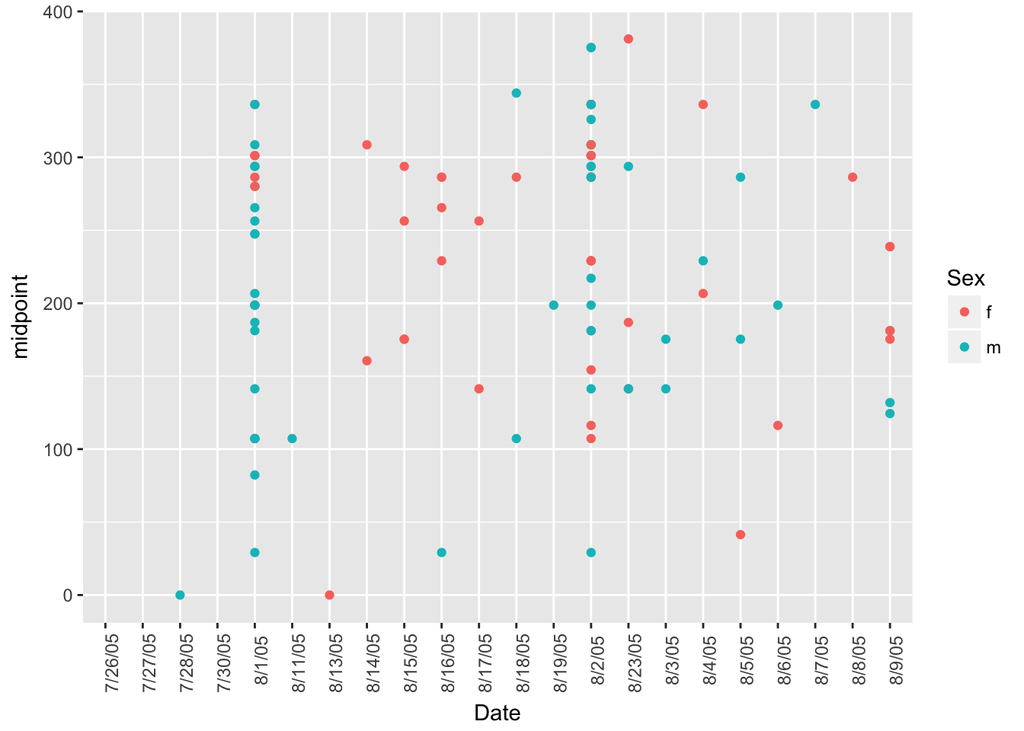

```r
ggplot(ccreek_fish_2005_return_time, aes(x = Date, y = midpoint, color = Sex)) +
  geom_point() +
  theme(axis.text.x = element_text(angle = 90, hjust =0.75))    # plot for c creek - edit name to match year you want
```

## Length of stay in creek

Determine the distribution of time that fish stay in the creek. Would be cool to look into male to female ratios in future, but I couldn’t figure out the code. (When summarising fish to have the number of days in stream, the column for sex would disappear)

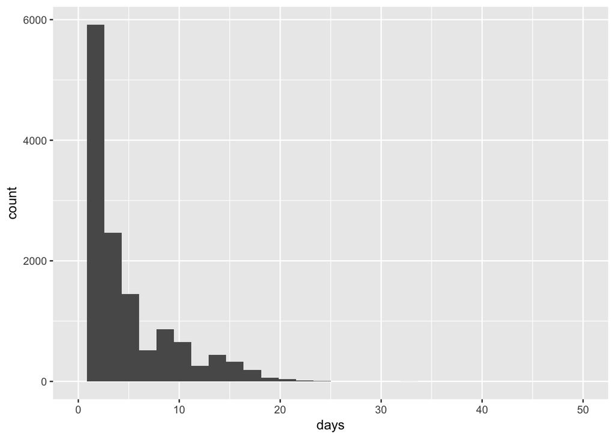

```r
## looks at all years at once...

fish_creek_stay_length <- master %>%
  #filter(Year == xxxx) %>%     ### remove hastag if you want to specify a year
  select(Year_Tag, Sex) %>%
  group_by(Year_Tag) %>%
  summarise("count" = n())


ggplot(fish_creek_stay_length, aes(x = count)) +
  geom_histogram() +
  labs(x = "days") +
  scale_x_continuous(limits = c(0, 50))
```

## Fish Density in section between years

A high fish density could mean preferable location of redds. More questions about density dependence can be asked, including how it affects the precision of homing. Again, it is important to change the year or creek section accordingly!!!

```r
location_count_2004_ccreek <- master %>%
  select(Year, Location, location_section) %>%
  filter(Year == 2004, Location == "c" ) %>%    #### Change the year or creek here!!!! Then change the name accordingly
  group_by(location_section) %>%
  summarise("number_of_fish" = n())

fish_count_per_section_ccreek <- ggplot(location_count_2004_ccreek, aes(x = location_section, y = number_of_fish)) +
  geom_bar(stat = "identity") +
  theme(axis.text.x = element_text(angle = 90, hjust =0.75)) +
  labs( x = "Location Section", y = "Number of fish")
```

A more detailed look at the section density but showing how it varies per year

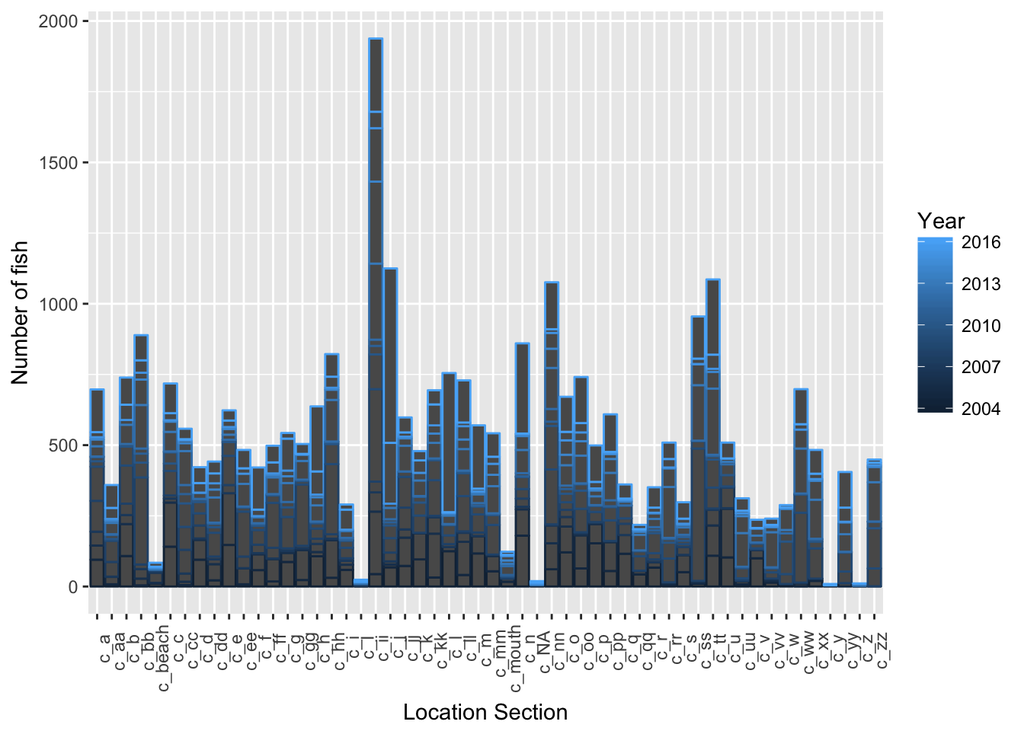

```r
# for c creek
location_count_per_year_ccreek<- master %>%
  select(Year, Location, location_section) %>%
  filter(Location == "c" ) %>%    #### Change the year or creek here!!!! Then change the name accordingly
  group_by(location_section, Year) %>%
  summarise("number_of_fish" = n())

ggplot(location_count_per_year_ccreek, aes(x = location_section, y = number_of_fish, color = Year)) +
  geom_bar(stat = "identity") +
  labs(x = "") +
  theme(axis.text.x = element_text(angle = 90, hjust =0.75)) +
  labs( x = "Location Section", y = "Number of fish")
```

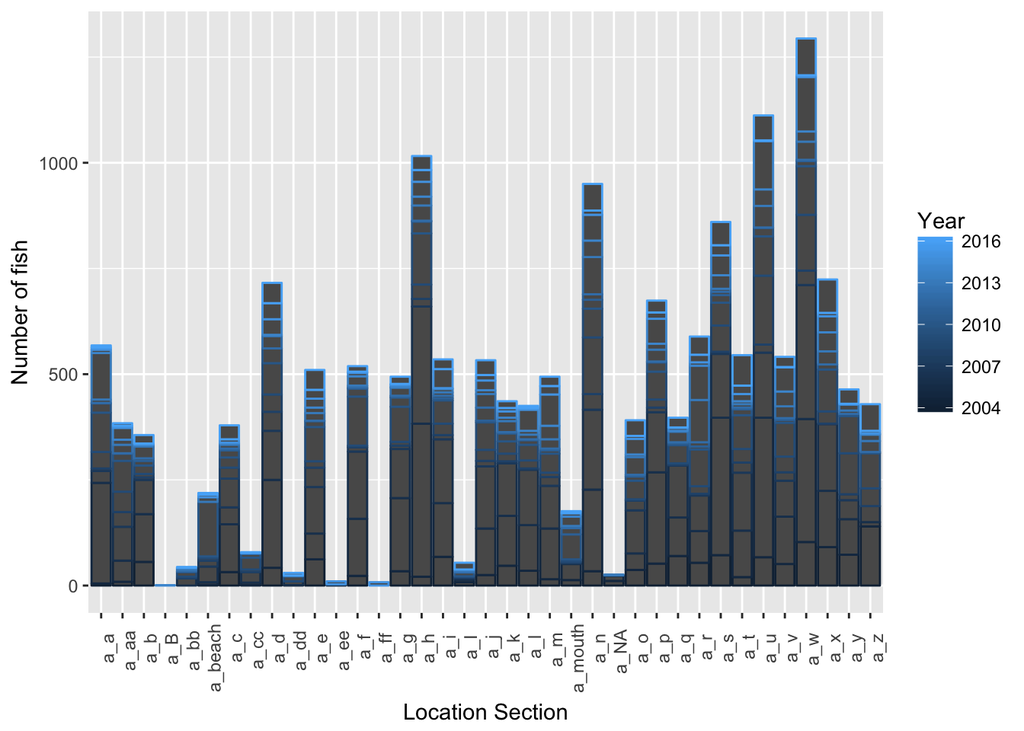

```r
# for a creek
location_count_per_year_acreek<- master %>%
  select(Year, Location, location_section) %>%
  filter(Location == "a" ) %>%    #### Change the year or creek here!!!! Then change the name accordingly
  group_by(location_section, Year) %>%
  summarise("number_of_fish" = n())

ggplot(location_count_per_year_acreek, aes(x = location_section, y = number_of_fish, color = Year)) +
  geom_bar(stat = "identity") +
  labs(x = "") +
  theme(axis.text.x = element_text(angle = 90, hjust =0.75)) +
  labs( x = "Location Section", y = "Number of fish")
```